# Analysis of Ft Riley white-tailed deer surveys

Analysis of a single year, highlighting some potential challenges.

Rexstad (CREEM, Univ St Andrews)https://www.creem.st-andrews.ac.uk/  
2021-10-25

```r
library(readxl)
library(Distance)
library(circular)
library(knitr)
library(plotrix)
```

# Acquire data

Analyse a single year of white-tailed deer spotlight survey data. Because each year’s survey is stored in a separate sheet of the spreadsheet, we can select what year we wish to analyse. The code below has selected the most recent year. We will talk about the earlier years later.

```r
spreadsheet.file <- "FortRileyDeerDistanceRData.xlsx"
year <- 2020
unit.dat <- as.data.frame(read_xlsx(path=spreadsheet.file, sheet=as.character(year)))
```

# Data organisation

We will do some organisation of the data, introducing an Area field, transforming radial distance and angle to perpendicular distances and establishing the units of measure for the perpendicular distances, the transect lengths and the units with which density estimates will be reported.

```r
unit.dat$Region.Label <- unit.dat$Unit
unit.dat$Area <- 1  #  produces density per sqkm
deg2rad <- function(deg) {(deg * pi) / (180)}
unit.dat$distance <- abs(unit.dat$radial * sin(deg2rad(unit.dat$Angle)))
riley.units <- convert_units("meter", "mile", "square kilometer")
```

# Exploratory data analysis

There is a total of 69 detections. As it is distance sampling, attention first focuses upon the distribution of the perpendicular distances. Note the `nc` argument will produce quite fine scale resolution of the histogram bars.

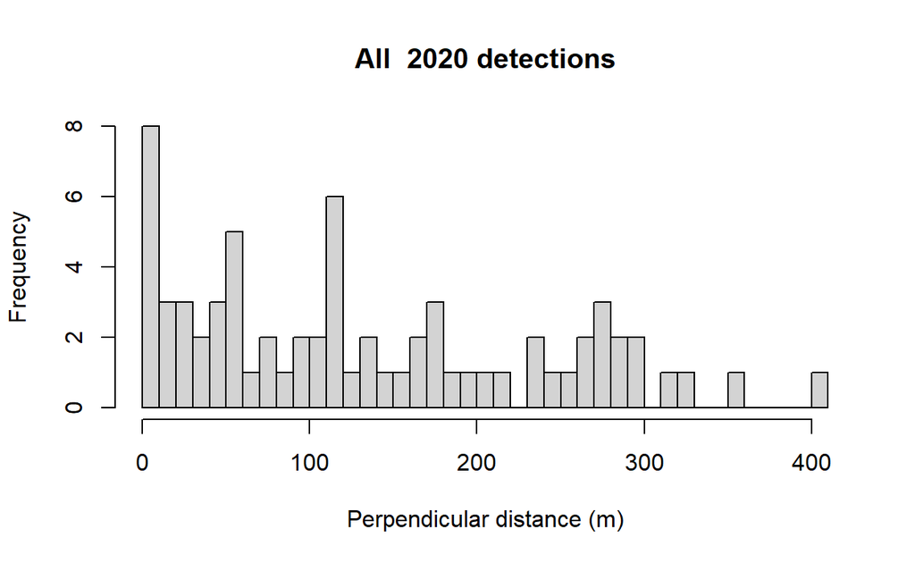

```r
hist(unit.dat$distance, nc=40, xlab="Perpendicular distance (m)", main=paste("All ", year, "detections"))
```

**Closer scrutiny of 2020 data**

If you chose to examine the 2020 data, you will notice a difficulty in the histogram of perpendicular distances.

There is an apparent small spike at small distances. Further investigation suggests this spike comes from potential rounding of bearings to zero.

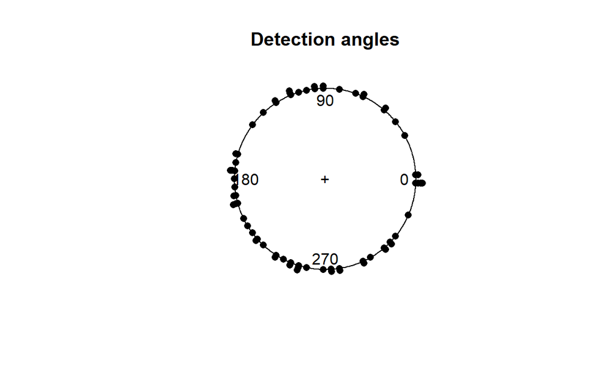

```r
plot.circular(unit.dat$Angle, stack=TRUE, main="Detection angles", units = "degrees")
```

What are the implications of this field procedure to our density estimates?

# Model fitting without truncation

```r
unic <- ds(unit.dat, transect="line", key="unif", adjustment = "cos",
           convert.units = riley.units)
hnc <- ds(unit.dat, transect="line", key="hn", adjustment = "cos",
          convert.units = riley.units)
hrc <- ds(unit.dat, transect="line", key="hr", adjustment = "cos",
          convert.units = riley.units)
```

## Assess model fit

Use the function `gof_ds()` to assess fit. Note, by default, with exact distance data you will not be provided with a $\chi^2$ goodness of fit test, just the Cramer-von Mises test. The Kolomogorov-Smirnov test is also not provided by default because it uses a bootstrap procedure that is quite slow.

```r
par(mfrow=c(1,3))
gof_ds(unic)
```

```
Goodness of fit results for ddf object

Distance sampling Cramer-von Mises test (unweighted)
Test statistic = 0.144646 p-value = 0.406311
```

```r
gof_ds(hnc)
```

```
Goodness of fit results for ddf object

Distance sampling Cramer-von Mises test (unweighted)
Test statistic = 0.142639 p-value = 0.412807
```

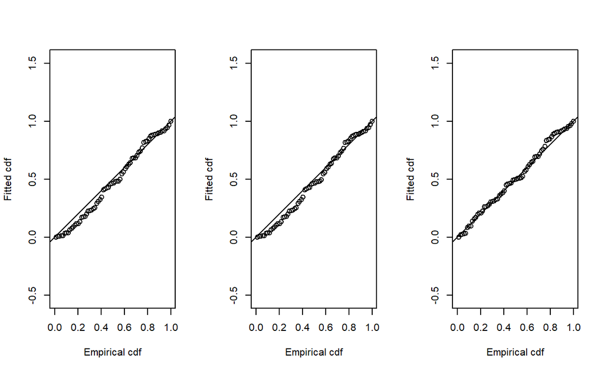

```
Goodness of fit results for ddf object

Distance sampling Cramer-von Mises test (unweighted)
Test statistic = 0.0528434 p-value = 0.85883
```

```r
gof_ds(hrc)
```

```r
par(mfrow=c(1,1))
```

With absolute measure of fit determined, also assess relative fit of competing models.

```r
AIC(unic, hnc, hrc)
```

```
     df      AIC
unic  1 808.6428
hnc   1 808.4803
hrc   3 807.4082
```

Both the relative and absolute measures of fit can be produced in a single table using `summarize_ds_models()`.

```r
kable(summarize_ds_models(unic, hnc, hrc)[ ,2:7], row.names = FALSE, digits=4)
```

| Key function | Formula | C-vM p-value | $\hat{P_a}$ | se($\hat{P_a}$) | $\Delta$AIC |
| --- | --- | --- | --- | --- | --- |
| Hazard-rate with cosine adjustment term of order 2 | ~1 | 0.8588 | 0.2021 | 0.0874 | 0.0000 |
| Half-normal | ~1 | 0.4128 | 0.5656 | 0.0552 | 1.0721 |
| Uniform with cosine adjustment term of order 1 | NA | 0.4063 | 0.5666 | 0.0420 | 1.2346 |

Examine the plot of the selected detection function to the data.

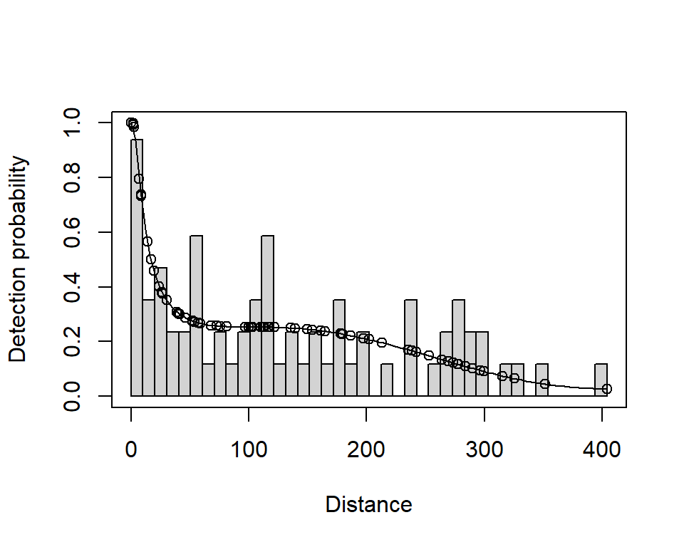

Figure 1: Hazard rate detection function fitted without truncation.

```r
plot(hrc, nc=40)
```

### Examine the summary of the detection function from the selected model.

```r
summary(hrc$ddf)
```

```
Summary for ds object
Number of observations :  69
Distance range         :  0  -  404.445
AIC                    :  807.4082

Detection function:
 Hazard-rate key function with cosine adjustment term of order 2

Detection function parameters
Scale coefficient(s):
            estimate        se
(Intercept) 2.392571 0.7675346

Shape coefficient(s):
                estimate        se
(Intercept) 3.039389e-08 0.2294531

Adjustment term coefficient(s):
               estimate        se
cos, order 2 -0.5955308 0.2057143


Strict monotonicity constraints were enforced.
                       Estimate           SE        CV
Average p             0.2021393   0.08737514 0.4322521
N in covered region 341.3487847 152.04592042 0.4454269

Strict monotonicity constraints were enforced.
```

### Examine the summary of the density estimates from the selected model.

```r
hrc$dht
```

```
Abundance and density estimates from distance sampling
Variance       : R2, N/L

Summary for clusters

Summary statistics:
  Region Area CoveredArea Effort  n k  ER     se.ER    cv.ER
1     U8    1    39.05346     30 69 2 2.3 0.3266667 0.142029

Abundance:
  Label Estimate       se       cv      lcl      ucl      df
1 Total 8.740551 3.976846 0.454988 3.650077 20.93031 45.7921

Density:
  Label Estimate       se       cv      lcl      ucl      df
1 Total 8.740551 3.976846 0.454988 3.650077 20.93031 45.7921

Summary for individuals

Summary statistics:
  Region Area CoveredArea Effort   n       ER     se.ER      cv.ER
1     U8    1    39.05346     30 107 3.566667 0.1577778 0.04423676
  mean.size    se.mean
1  1.550725 0.09356133

Abundance:
  Label Estimate       se        cv      lcl      ucl       df
1 Total 13.55419 5.889426 0.4345097 5.909758 31.08689 66.90536

Density:
  Label Estimate       se        cv      lcl      ucl       df
1 Total 13.55419 5.889426 0.4345097 5.909758 31.08689 66.90536

Expected cluster size
  Region Expected.S se.Expected.S cv.Expected.S
1  Total   1.550725     0.1516488    0.09779223
2  Total   1.550725     0.1516488    0.09779223
```

Be sure you understand all the elements presented in the output.

# Questions

- Assess the plausibility of the detection function
- Does the estimate of white-tail density seem biologically realistic?

**Off to a rough start**

Clearly analysis of distance sampling data is not as simple as press the run button and write down the answer produced by the computer. We will have to work harder and smarter to produce credible analyses of our data.

The perils of a spike at 0 coupled with dubious use of the hazard rate key function, coupled with no truncation, coupled with unquestioned use of model selection tools; result in unreasonable model fits.

This model has the lowest AIC and a goodness of fit statistic that passes the threshold. What does it suggest?